# Multilevel Models of the MHoM Measure

Brandon Foster, Ph.D.

16 December, 2017, 13:22

Load the data and pacakges necessary for analyses.

## Null Model

This first model explores the variance in the outcome that can be attributed to the nested structure of the data. Key outcome of interest is the ICC statistic, which establishes the correlation in MCAS scores between any two students chosen at random within a class.

### Model summary

Results below show the number of students in each class, which can provide context for the estimates of teacher-level variance. Results indicate that four teachers have only one student, which could be problematic. The ICC for this model is .25 [.04-.42], indicating that the average correaltion between any two students chosen at random within a class in their MCAS scores is r = .25. However, the wide confidence intervals indicate some uncertainty around this estiamte. Regardless, this is notable variance between teachers, and suggests the use of a multilevel model is worthwhile. The average difference between a teachers within class estimated mean and the grand mean is provided in the subsequent table.

| Var1 | n |
| --- | --- |
| Y3_09_001 | 2 |
| Y3_09_002 | 5 |
| Y3_09_003 | 19 |
| Y3_09_004 | 53 |
| Y3_09_005 | 1 |
| Y3_09_006 | 1 |
| Y3_09_007 | 70 |
| Y3_09_008 | 1 |
| Y3_09_009 | 26 |
| Y3_09_010 | 19 |
| Y3_09_011 | 1 |
| Y3_09_012 | 35 |
| Y3_09_013 | 23 |
| Y3_09_014 | 24 |

```
## start par. =  0.6744288 fn =  660.6734
## At return
## eval:  14 fn:      660.43775 par: 0.577918
```

```
## summary from lme4 is returned
## some computational error has occurred in lmerTest
```

```
## Linear mixed model fit by maximum likelihood  ['lmerMod']
## Formula: g10_c ~ 1 + (1 | ID)
##    Data: m_vars
##
##      AIC      BIC   logLik deviance df.resid
##    666.4    677.0   -330.2    660.4      251
##
## Scaled residuals:
##     Min      1Q  Median      3Q     Max
## -4.4159 -0.4133  0.1448  0.5844  1.8388
##
## Random effects:
##  Groups   Name        Variance Std.Dev.
##  ID       (Intercept) 0.2430   0.4929
##  Residual             0.7275   0.8529
## Number of obs: 254, groups:  ID, 12
##
## Fixed effects:
##             Estimate Std. Error t value
## (Intercept)  0.09616    0.16882    0.57
```

```
## summary from lme4 is returned
## some computational error has occurred in lmerTest
## summary from lme4 is returned
## some computational error has occurred in lmerTest
```

```
## # A tibble: 1 x 3
##         ICC `Lower 95%` `Upper 95%`
##       <dbl>       <dbl>       <dbl>
## 1 0.2503686  0.04909347   0.4181546
```

Variation in average 10th grade MCAS scores between teachers

| grpvar | term | grp | condval |
| --- | --- | --- | --- |
| ID | (Intercept) | Y3_09_004 | -0.742 |
| ID | (Intercept) | Y3_09_012 | -0.606 |
| ID | (Intercept) | Y3_09_003 | -0.417 |
| ID | (Intercept) | Y3_09_010 | -0.396 |
| ID | (Intercept) | Y3_09_009 | 0.023 |
| ID | (Intercept) | Y3_09_014 | 0.130 |
| ID | (Intercept) | Y3_09_002 | 0.132 |
| ID | (Intercept) | Y3_09_013 | 0.167 |
| ID | (Intercept) | Y3_09_005 | 0.290 |
| ID | (Intercept) | Y3_09_001 | 0.439 |
| ID | (Intercept) | Y3_09_006 | 0.439 |
| ID | (Intercept) | Y3_09_007 | 0.540 |

### Interogation of model assumptions

Using the Hox (2010) method, assumptions of the model are examined first with intercept-only model for the presence of gross violations.

These assumptions inculde:

- Normality of the residuals at level-1 and level-2: This can be examined through qq-norm plots of the residuals, standardized residuals vs. normal value plots, standardized rediduals vs. predicted plots.
- Equal variance of the residual erros in all groups: This can be examined with a one way analysis of variance on the absolute values of the residuals.

Issues in any of these follow-up analyses are typically fixed by removing outliers, applying a normalizing transformation to the outcome, or including dummy variables in the subsequent regression to idnetify outlier groups.

*Exploring normality of the residuals at level-1:*

QQ-norm plot of the resiudals, with associated confidence band. Note, because these are 95% confidence bands, we expect about 13 students to fall outside the bands (i.e., .05 * 254 students). Note, because the sample size was small, I simulated a normal distribution using the summary data from the grade 10 MCAS vector and plotted these q-q norm plots next to the original data so that I could be sure deviations were not due to the sample size. It is obvious when looking at these plots which one is not like the other (i.e., is the actual q-q norm plot for the model). Like the plot above, problematic data points are the individuals who score low on the MCAS. These deviations can be due to a number of factors, such as: the presence of outliers, the need to transform the outcome variable, the presence of missing covariates, etc. The plots indicate some potential issues with normality, with more than 13 students falling outside of the confidence intervals.

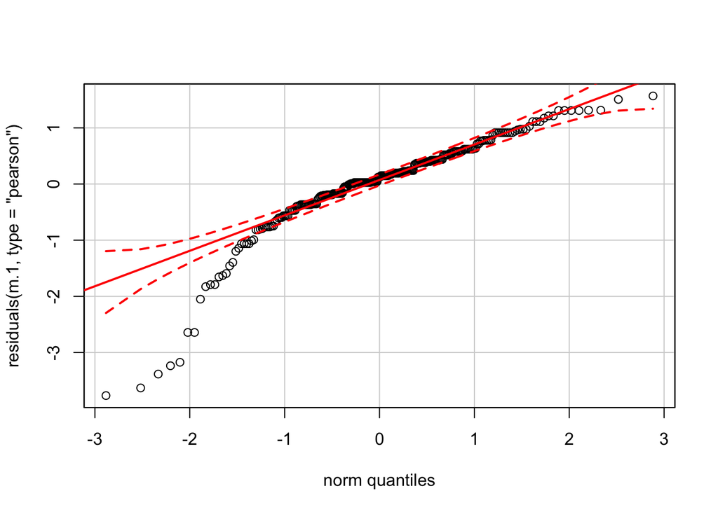

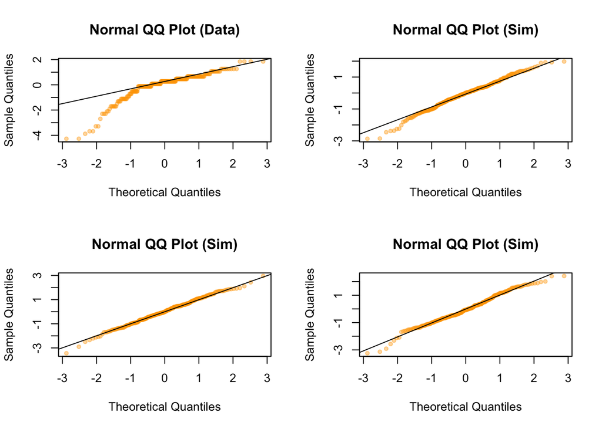

Here the standardized residuals vs. fitted plot is provided, which shows some dispersion of the variance for students with low MCAS scores, indicating that the model over predicts the MCAS scores for these students.

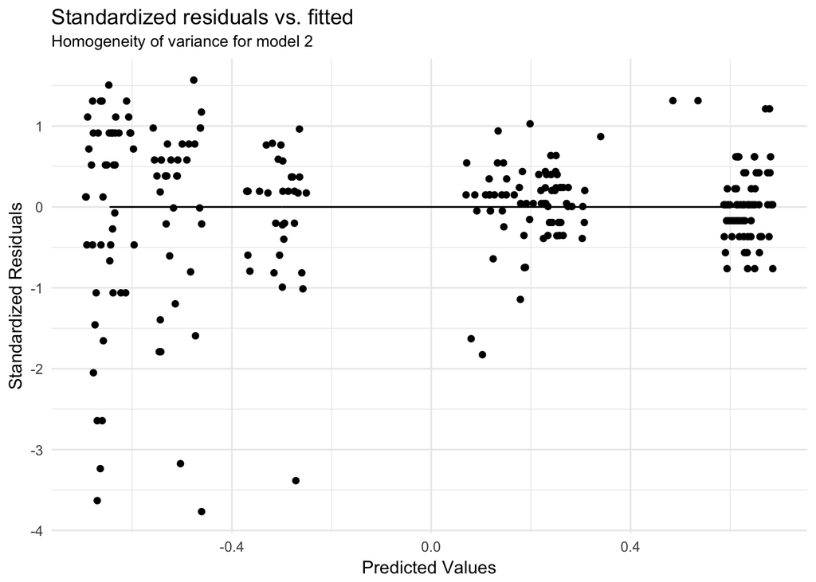

Box plots for the level-1 residuals. Outliers clearly present for low MCAS scorers.

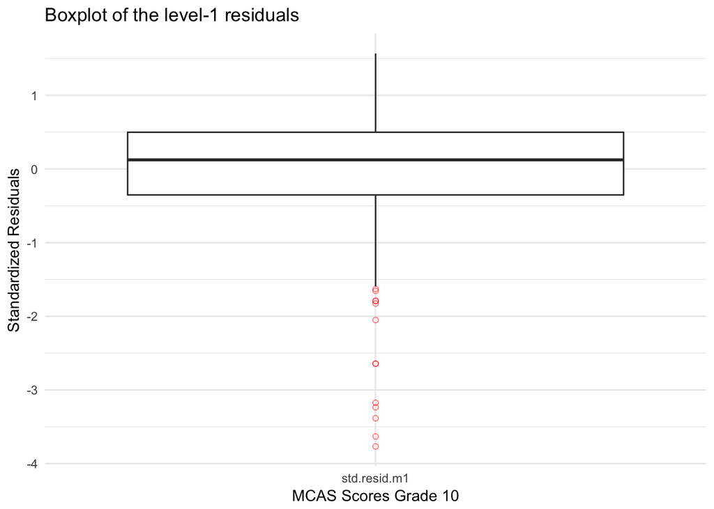

*Equal variance of the residual erros in all groups:*

Run a levene’s test for the absolute value of the residuals by “ID.” Note, since the assumption is that the variance is not going to differ, we would hope to see NO STATISTICAL DIFFERENCES in the following procedure (i.e. p>0.05). Results indicate that the varinces aren’t equal across groups. This is likely due to the sample size of students in classes.

```
##        term  df    sumsq   meansq statistic      p.value
## 1        ID  11 101.6881 9.244372  3.018579 0.0008566116
## 2 Residuals 242 741.1229 3.062491        NA           NA
```

*Level-2 Random Effects*

QQ-norm plot of level-2 random effects looks good. Teachers 9 through 11 have more variance student 10th grade MCAS scores. Might need to followup. What’s clear is that issues with the model are at L-1. So, let’s try and remove outliers and see if things change.

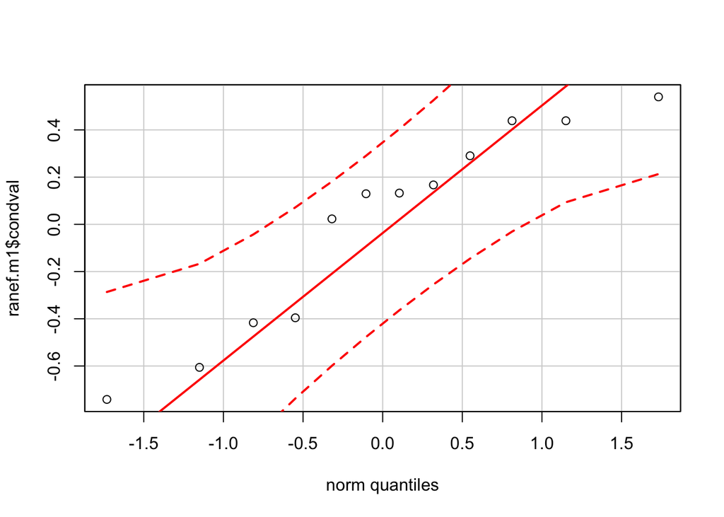

*Level-1 Outlier Analysis*

First, we will pull out the individuals with standardized residuals > 2.5, which is how `LMERConvenienceFunctions` works. Results show all of the outlier cases come from teacher 4, 12, 10. Not surprisngly, based on the residual plots above, these cases also are among the lowest scores on the MCAS.

```
## Currently generic markdown table using pandoc is not supported.
```

Number of outliers for each teacher

| ID | Outlier Count |
| --- | --- |
| Y3_09_004 | 5 |
| Y3_09_012 | 2 |
| Y3_09_010 | 1 |
| Y3_09_001 | 0 |
| Y3_09_002 | 0 |
| Y3_09_003 | 0 |
| Y3_09_005 | 0 |
| Y3_09_006 | 0 |
| Y3_09_007 | 0 |
| Y3_09_008 | 0 |
| Y3_09_009 | 0 |
| Y3_09_011 | 0 |
| Y3_09_013 | 0 |
| Y3_09_014 | 0 |

```
## Currently generic markdown table using pandoc is not supported.
```

| Grade 10 MCAS score | Freq |
| --- | --- |
| 214 | 3 |
| 216 | 3 |
| 218 | 2 |

Let’s try removing them from the analyses to see if that fixes things. You’ll notice that the results look similar, and the problems remain with respect to the non-normaliry of the L-1 residuals. The easiest way to ensure that standard errors are not biased is to utilize a non-parametric bootstrap in downstream analyses.

```
## start par. =  0.7360387 fn =  497.6615
## At return
## eval:  13 fn:      497.66149 par: 0.737484
```

```
## summary from lme4 is returned
## some computational error has occurred in lmerTest
```

```
## Linear mixed model fit by maximum likelihood  ['lmerMod']
## Formula: g10_c ~ 1 + (1 | ID)
##    Data: m_vars_no_outliers
##
##      AIC      BIC   logLik deviance df.resid
##    503.7    514.2   -248.8    497.7      243
##
## Scaled residuals:
##      Min       1Q   Median       3Q      Max
## -3.12227 -0.53720  0.04311  0.63097  2.18429
##
## Random effects:
##  Groups   Name        Variance Std.Dev.
##  ID       (Intercept) 0.2179   0.4668
##  Residual             0.4007   0.6330
## Number of obs: 246, groups:  ID, 12
##
## Fixed effects:
##             Estimate Std. Error t value
## (Intercept)   0.2221     0.1537   1.445
```

```
## summary from lme4 is returned
## some computational error has occurred in lmerTest
```

```
## # A tibble: 1 x 1
##         ICC
##       <dbl>
## 1 0.3522823
```

```
## summary from lme4 is returned
## some computational error has occurred in lmerTest
```

```
##       2.5%      97.5%
## 0.08145662 0.54060363
```

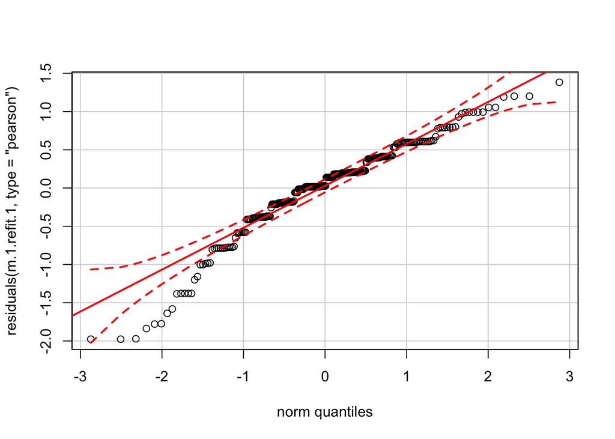

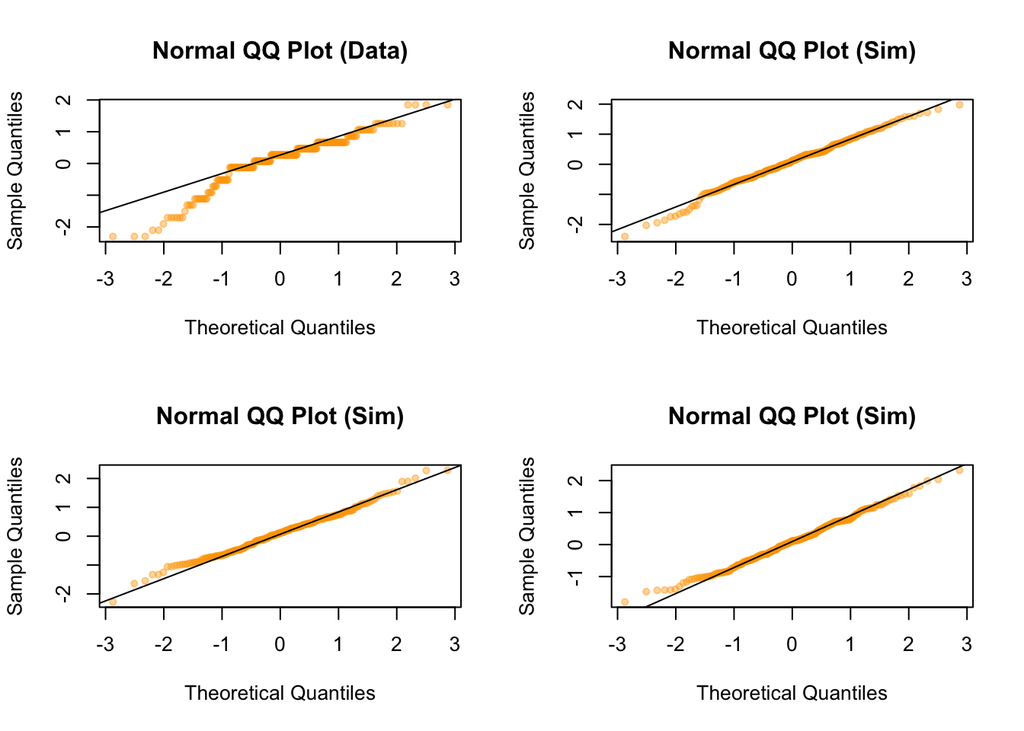

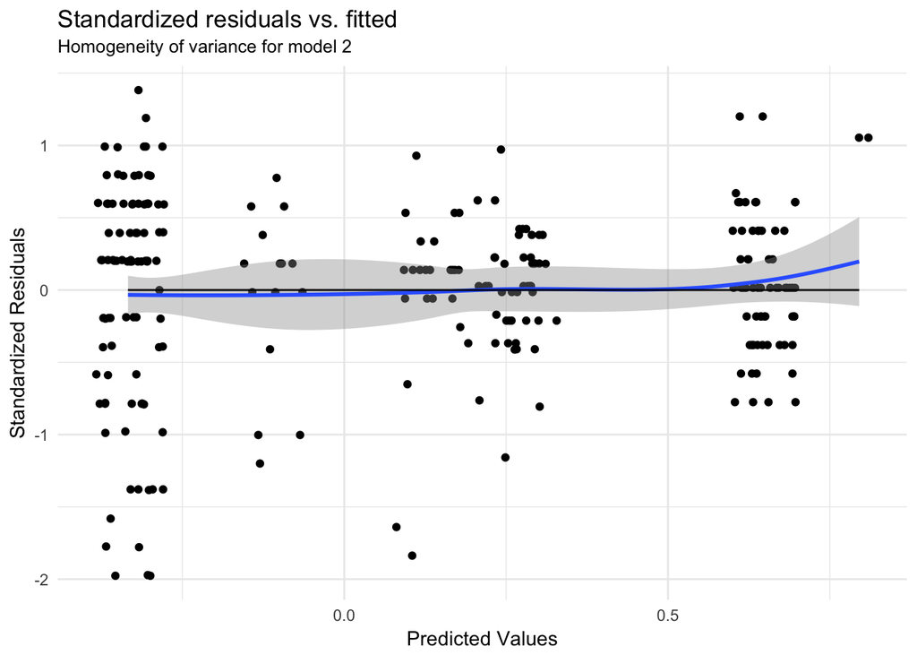

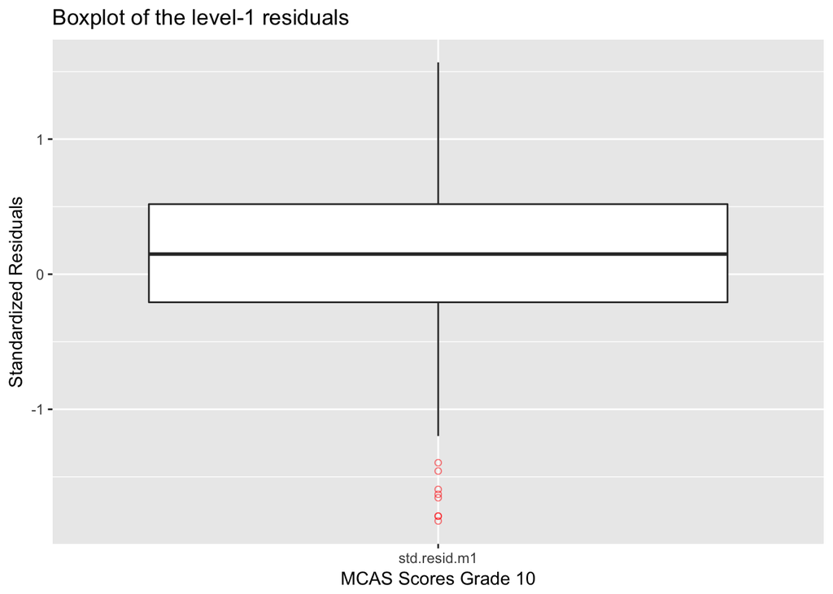

### Final model with bias corrections

Final null model with nonparametric bootstrap corrected standard errors.

Non-parametric bootstrap estimates for the null model

| Variable | Original Estimate | Median Bootstrap Estimate | Bootstrap SE | Bias |
| --- | --- | --- | --- | --- |
| Intercept | 0.096 | 0.17 | 0.207 | 0.09 |

## Model 2: Prior achievement

The next model investigates the association between prior MCAS achievement and current acheivement. Prior MCAS scores are entered into the model first because it is assumed that they will acount for the largest share of vairance in current MCAS scores.

### Model summary

Not surprisingly, results show that grade 8 MCAS scores is a significant predictor of grade 10 MCAS scores.

```
## start par. =  0.6744288 fn =  490.7023
## At return
## eval:  17 fn:      480.53627 par: 0.179649
```

```
## Linear mixed model fit by maximum likelihood t-tests use Satterthwaite
##   approximations to degrees of freedom [lmerMod]
## Formula: g10_c ~ g8_c + (1 | ID)
##    Data: m_vars
##
##      AIC      BIC   logLik deviance df.resid
##    488.5    502.7   -240.3    480.5      250
##
## Scaled residuals:
##     Min      1Q  Median      3Q     Max
## -4.3371 -0.4969  0.1233  0.6116  2.7147
##
## Random effects:
##  Groups   Name        Variance Std.Dev.
##  ID       (Intercept) 0.01226  0.1107
##  Residual             0.37995  0.6164
## Number of obs: 254, groups:  ID, 12
##
## Fixed effects:
##              Estimate Std. Error        df t value Pr(>|t|)
## (Intercept)   0.02204    0.05555   9.32000   0.397      0.7
## g8_c          0.75213    0.04335 136.60000  17.350   <2e-16 ***
## ---
## Signif. codes:  0 '***' 0.001 '**' 0.01 '*' 0.05 '.' 0.1 ' ' 1
##
## Correlation of Fixed Effects:
##      (Intr)
## g8_c 0.039
```

Non-parametric bootstrap estimates for the null model

[output not shown]

As such, the model which included prior achievement fit better than the null model.

```
##     term df      AIC      BIC    logLik deviance statistic Chi.Df
## 1    ..1  3 666.4377 677.0497 -330.2189 660.4377        NA     NA
## 2 object  4 488.5363 502.6856 -240.2681 480.5363  179.9015      1
##        p.value
## 1           NA
## 2 5.092514e-41
```

Further, the proprotion of variance explained by model 2, as established using Nakagawa and Schielzeth’s (2013) method, was 59%.

The Nakagawa and Schielzeth (2013) method for calculating the proportion of variance explained by the fixed predictors

| Effect | F | v1 | v2 | ncp | Rsq | upper.CL | lower.CL |
| --- | --- | --- | --- | --- | --- | --- | --- |
| Model | 364.91 | 1 | 253 | 364.91 | 0.591 | 0.654 | 0.524 |
| g8_c | 364.91 | 1 | 253 | 364.91 | 0.591 | 0.654 | 0.524 |

Useful plots for the model are found below.

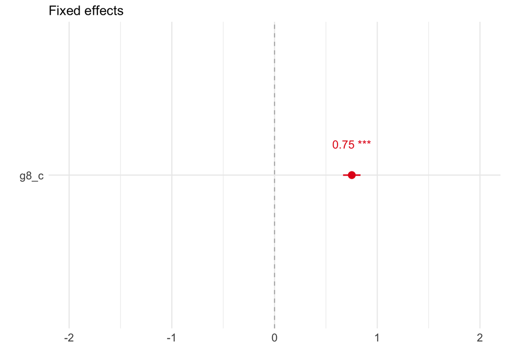

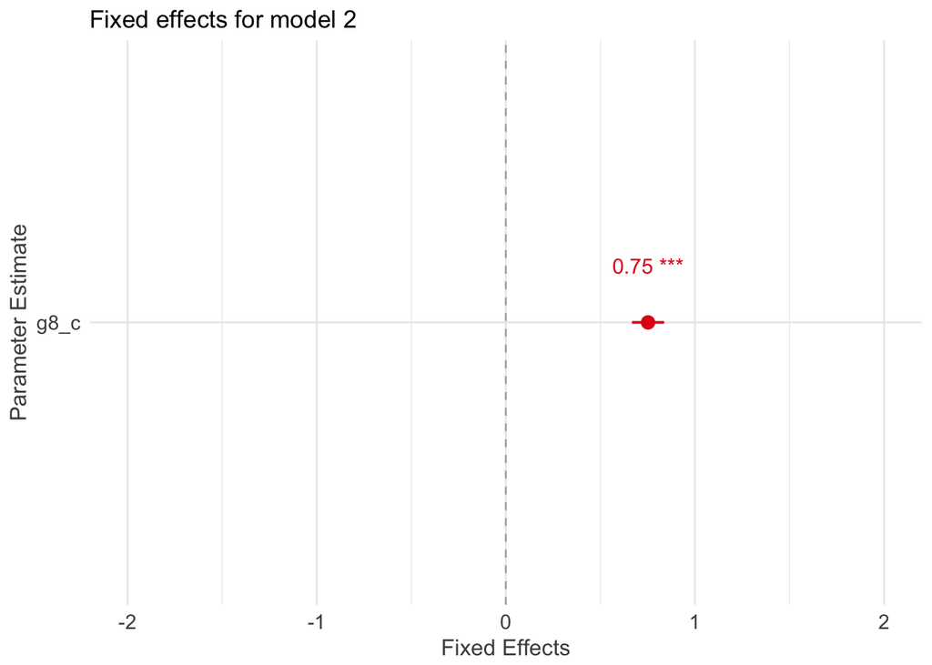

```
## `sjp.lmer()` will become deprecated in the future. Please use `plot_model()` instead.
```

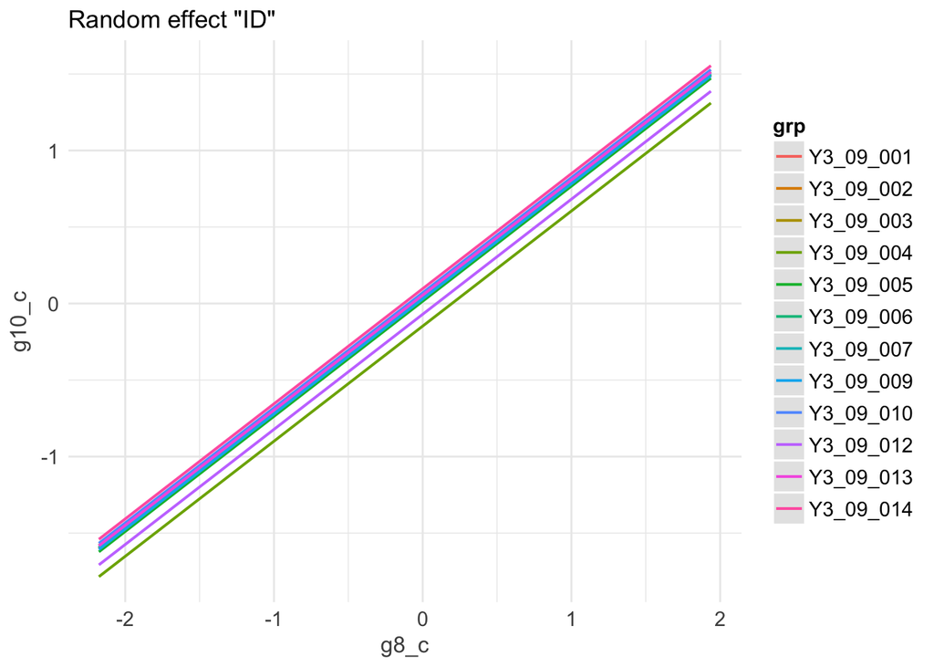

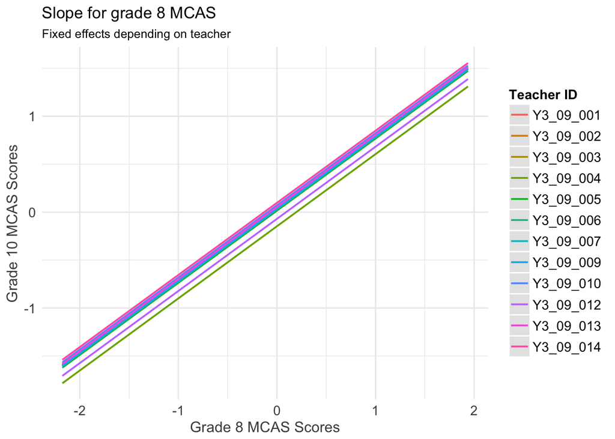

### Exploring a quadratic effect

Next, a quadratic effect is added to the model for 10th grade MCAS scores. Results indicate a significant effect for quadratic MCAS, with the overall model fitting better than model 2, with just a linear MCAS effect.

```
## start par. =  0.6744288 fn =  448.3764
## At return
## eval:  19 fn:      438.72086 par: 0.142784
```

```
## Linear mixed model fit by maximum likelihood t-tests use Satterthwaite
##   approximations to degrees of freedom [lmerMod]
## Formula: g10_c ~ g8_c + g8_c2 + (1 | ID)
##    Data: m_vars
##
##      AIC      BIC   logLik deviance df.resid
##    448.7    466.4   -219.4    438.7      249
##
## Scaled residuals:
##     Min      1Q  Median      3Q     Max
## -3.9579 -0.5263 -0.0419  0.5412  3.1198
##
## Random effects:
##  Groups   Name        Variance Std.Dev.
##  ID       (Intercept) 0.006612 0.08132
##  Residual             0.324332 0.56950
## Number of obs: 254, groups:  ID, 12
##
## Fixed effects:
##              Estimate Std. Error        df t value Pr(>|t|)
## (Intercept)   0.21289    0.05488  15.57000   3.879  0.00139 **
## g8_c          0.71118    0.03976  95.68000  17.887  < 2e-16 ***
## g8_c2        -0.20689    0.03062 242.68000  -6.758 1.03e-10 ***
## ---
## Signif. codes:  0 '***' 0.001 '**' 0.01 '*' 0.05 '.' 0.1 ' ' 1
##
## Correlation of Fixed Effects:
##       (Intr) g8_c
## g8_c  -0.060
## g8_c2 -0.530  0.173
```

```
##         R  original  bootBias   bootSE  bootMed
## beta1 500  0.212890  0.032810 0.108270  0.21919
## beta2 500  0.711183 -0.055423 0.099685  0.67197
## beta3 500 -0.206888 -0.001819 0.084116 -0.21570
## sigma 500  0.569501 -0.010866 0.062029  0.56187
## sig01 500  0.081315  0.040105 0.122774  0.09502
```

[output not shown]

```
## Data: m_vars
## Models:
## ..1: g10_c ~ g8_c + (1 | ID)
## object: g10_c ~ g8_c + g8_c2 + (1 | ID)
##        Df    AIC    BIC  logLik deviance  Chisq Chi Df Pr(>Chisq)
## ..1     4 488.54 502.69 -240.27   480.54
## object  5 448.72 466.41 -219.36   438.72 41.815      1  1.003e-10 ***
## ---
## Signif. codes:  0 '***' 0.001 '**' 0.01 '*' 0.05 '.' 0.1 ' ' 1
```

Proportion of variance in the outcome attributed to the quadratic trend is roughly 16%.

The Nakagawa and Schielzeth (2013) method for calculating the proportion of variance explained by the fixed predictors

| Effect | F | v1 | v2 | ncp | Rsq | upper.CL | lower.CL |
| --- | --- | --- | --- | --- | --- | --- | --- |
| Model | 240.910 | 2 | 253 | 481.820 | 0.656 | 0.710 | 0.598 |
| g8_c | 375.187 | 1 | 253 | 375.187 | 0.597 | 0.659 | 0.531 |
| g8_c2 | 46.723 | 1 | 253 | 46.723 | 0.156 | 0.241 | 0.085 |

A plot of the quadratic trend.

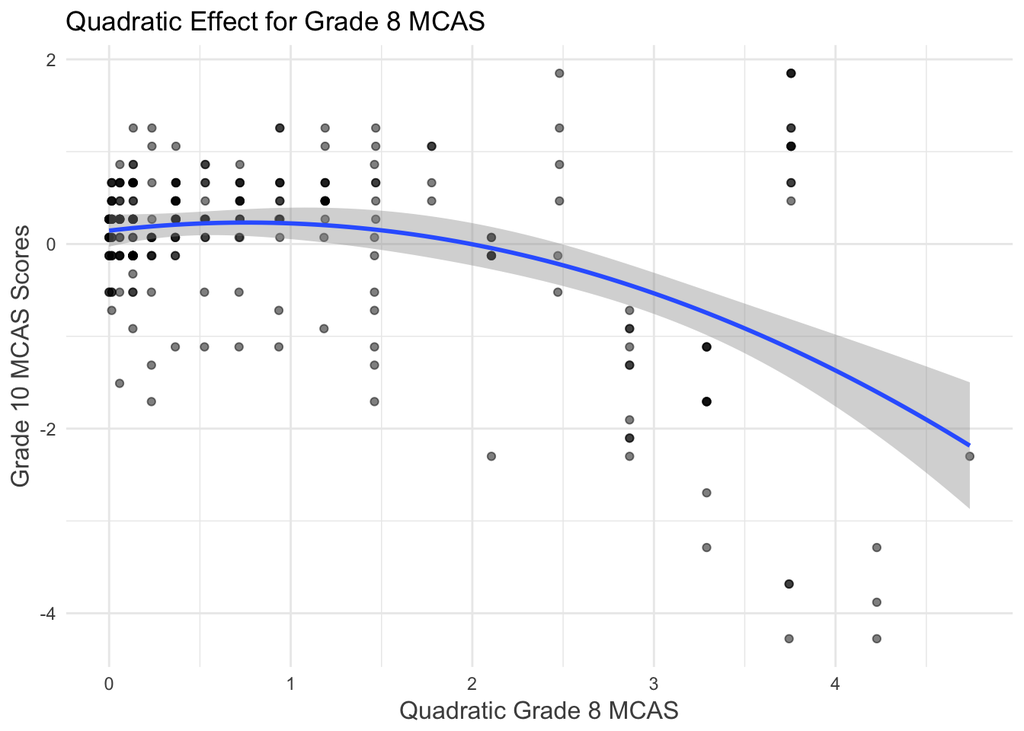

## Model 3: Prior achievement + student characteristics

The next model investigates the association between prior MCAS achievement and other student characteristics with current acheivement.

### Model summary

Results show a significant positive effect for students who are not special education, indicating that these students score almost 1/2 a standard deviation higher on the outcome than their peers with IEP statuses. There are some significant effects for ELL status, but it is hard to take stock in these results with so few students being ELL.

```
## start par. =  0.6744288 fn =  427.6983
## At return
## eval:  19 fn:      417.41956 par: 0.107613
```

```
## Linear mixed model fit by maximum likelihood t-tests use Satterthwaite
##   approximations to degrees of freedom [lmerMod]
## Formula:
## g10_c ~ g8_c + g8_c2 + ELL_recode + Lunch_N + SPED_N + relevel(Race_N,
##     ref = "Caucasian") + (1 | ID)
##    Data: m_vars
##
##      AIC      BIC   logLik deviance df.resid
##    443.4    489.4   -208.7    417.4      241
##
## Scaled residuals:
##     Min      1Q  Median      3Q     Max
## -3.7776 -0.5503 -0.0361  0.5755  3.1036
##
## Random effects:
##  Groups   Name        Variance Std.Dev.
##  ID       (Intercept) 0.003474 0.05894
##  Residual             0.299943 0.54767
## Number of obs: 254, groups:  ID, 12
##
## Fixed effects:
##                                                     Estimate Std. Error
## (Intercept)                                         -0.35953    0.16039
## g8_c                                                 0.67911    0.04107
## g8_c2                                               -0.19490    0.03037
## ELL_recodeOTHER                                      1.05541    0.40148
## ELL_recodeSEI                                        0.18971    0.18192
## Lunch_NP                                             0.14956    0.08727
## Lunch_NR                                             0.01661    0.14497
## SPED_NNot special ed                                 0.46673    0.14154
## relevel(Race_N, ref = "Caucasian")African American  -0.05003    0.13127
## relevel(Race_N, ref = "Caucasian")Asian              0.15572    0.13015
## relevel(Race_N, ref = "Caucasian")Multiple races     0.15093    0.33228
##                                                           df t value
## (Intercept)                                        204.36000  -2.242
## g8_c                                                97.63000  16.535
## g8_c2                                              234.54000  -6.417
## ELL_recodeOTHER                                    247.07000   2.629
## ELL_recodeSEI                                      252.76000   1.043
## Lunch_NP                                           253.80000   1.714
```

[output cut: 28 more lines]

```
## SPED_NNtspe -0.857 -0.234  0.085  0.111 -0.098  0.047  0.021
## r(R_N,r="CA -0.177  0.135 -0.150  0.103  0.017  0.155  0.189  0.067
## r(R_N,r="C" -0.049  0.037  0.133  0.005 -0.027 -0.096 -0.059 -0.001  0.053
## r(R_N,r="Cr -0.192 -0.047 -0.098  0.042 -0.013 -0.045  0.022  0.239  0.069
##             r(Rr="
## g8_c
## g8_c2
## ELL_rcOTHER
## ELL_recdSEI
## Lunch_NP
## Lunch_NR
## SPED_NNtspe
## r(R_N,r="CA
## r(R_N,r="C"
## r(R_N,r="Cr  0.025
```

```
##     term df      AIC      BIC    logLik deviance statistic Chi.Df
## 1    ..1  5 448.7209 466.4075 -219.3604 438.7209        NA     NA
## 2 object 13 443.4196 489.4049 -208.7098 417.4196   21.3013      8
##       p.value
## 1          NA
## 2 0.006388697
```

Overall, the model accounts for about 68% of the variance in outcomes, with the relative contribution of the student covariates being very small, even for SPED status.

The Nakagawa and Schielzeth (2013) method for calculating the proportion of variance explained by the fixed predictors

|  | Effect | F | v1 | v2 | ncp | Rsq | upper.CL | lower.CL |
| --- | --- | --- | --- | --- | --- | --- | --- | --- |
| 1 | Model | 56.141 | 10 | 253 | 561.412 | 0.689 | 0.742 | 0.640 |
| 2 | g8_c | 295.991 | 1 | 253 | 295.991 | 0.539 | 0.608 | 0.466 |
| 3 | g8_c2 | 41.863 | 1 | 253 | 41.863 | 0.142 | 0.225 | 0.073 |
| 8 | SPED_NNot special ed | 10.907 | 1 | 253 | 10.907 | 0.041 | 0.101 | 0.007 |
| 4 | ELL_recodeOTHER | 6.842 | 1 | 253 | 6.842 | 0.026 | 0.078 | 0.002 |
| 6 | Lunch_NP | 2.939 | 1 | 253 | 2.939 | 0.011 | 0.051 | 0.000 |
| 10 | relevel(Race_N, ref = “Caucasian”)Asian | 1.423 | 1 | 253 | 1.423 | 0.006 | 0.038 | 0.000 |
| 5 | ELL_recodeSEI | 1.082 | 1 | 253 | 1.082 | 0.004 | 0.035 | 0.000 |
| 11 | relevel(Race_N, ref = “Caucasian”)Multiple races | 0.205 | 1 | 253 | 0.205 | 0.001 | 0.023 | 0.000 |
| 9 | relevel(Race_N, ref = “Caucasian”)African American | 0.146 | 1 | 253 | 0.146 | 0.001 | 0.022 | 0.000 |
| 7 | Lunch_NR | 0.013 | 1 | 253 | 0.013 | 0.000 | 0.020 | 0.000 |

## Model 4: Prior achievement + student characteristics + teacher characteristics

The model above is expanded by adding covariates for the teacher characteristics.

### Model summary

Results show a negative effect for PD_NLow and CYears_N11-15. In addition, the overall test of model fit showed that model 4 fit the data better than model 3.

```
## start par. =  0.6744288 fn =  421.0126
## At return
## eval:  14 fn:      399.25527 par:  0.00000
```

```
## Linear mixed model fit by maximum likelihood t-tests use Satterthwaite
##   approximations to degrees of freedom [lmerMod]
## Formula:
## g10_c ~ g8_c + g8_c2 + ELL_recode + Lunch_N + SPED_N + relevel(Race_N,
##     ref = "Caucasian") + Gender_N + CYears_N + PD_N + (1 | ID)
##    Data: m_vars
##
##      AIC      BIC   logLik deviance df.resid
##    439.3    510.0   -199.6    399.3      234
##
## Scaled residuals:
##     Min      1Q  Median      3Q     Max
## -3.7591 -0.5443 -0.0116  0.5378  3.1286
##
## Random effects:
##  Groups   Name        Variance Std.Dev.
##  ID       (Intercept) 0.000    0.000
##  Residual             0.282    0.531
## Number of obs: 254, groups:  ID, 12
##
## Fixed effects:
##                                                     Estimate Std. Error
## (Intercept)                                          0.65993    0.44619
## g8_c                                                 0.61671    0.04532
## g8_c2                                               -0.22139    0.03181
## ELL_recodeOTHER                                      1.05378    0.38914
## ELL_recodeSEI                                        0.23664    0.17689
## Lunch_NP                                             0.12473    0.08634
## Lunch_NR                                            -0.02583    0.14297
## SPED_NNot special ed                                 0.42743    0.13981
## relevel(Race_N, ref = "Caucasian")African American  -0.09957    0.13120
## relevel(Race_N, ref = "Caucasian")Asian              0.13176    0.12715
## relevel(Race_N, ref = "Caucasian")Multiple races     0.11824    0.32522
## Gender_NMALE                                         0.76552    0.39581
## CYears_N11-15                                       -0.93717    0.47377
## CYears_N2-5                                         -1.39361    0.81629
## CYears_N6-10                                        -0.78863    0.40518
## CYears_Nmore than 20                                 0.33768    0.66662
## PD_NLow                                             -1.06407    0.40960
## PD_NMedium                                          -0.12285    0.11236
```

[output cut: 25 more lines]

```
## Lunch_NP                                            0.14980
## Lunch_NR                                            0.85677
## SPED_NNot special ed                                0.00247 **
## relevel(Race_N, ref = "Caucasian")African American  0.44859
## relevel(Race_N, ref = "Caucasian")Asian             0.30108
## relevel(Race_N, ref = "Caucasian")Multiple races    0.71647
## Gender_NMALE                                        0.05422 .
## CYears_N11-15                                       0.04900 *
## CYears_N2-5                                         0.08900 .
## CYears_N6-10                                        0.05271 .
## CYears_Nmore than 20                                0.61290
## PD_NLow                                             0.00993 **
## PD_NMedium                                          0.27529
## ---
## Signif. codes:  0 '***' 0.001 '**' 0.01 '*' 0.05 '.' 0.1 ' ' 1
```

```
##
## Correlation matrix not shown by default, as p = 18 > 12.
## Use print(x, correlation=TRUE)  or
##   vcov(x)     if you need it
```

```
##     term df      AIC      BIC    logLik deviance statistic Chi.Df
## 1    ..1 13 443.4196 489.4049 -208.7098 417.4196        NA     NA
## 2 object 20 439.2553 510.0020 -199.6276 399.2553  18.16429      7
##      p.value
## 1         NA
## 2 0.01125034
```

Overall, the model accounts for about 72% of the variance in the outcome. Again, prior MCAS and SPED status are the most important preditors in the model. The reduction in varaince accounted for by prior MCAS is likely due to shared variance with other variables in the model. It is notable that the variance remaining at the teacher-level is 0.

The Nakagawa and Schielzeth (2013) method for calculating the proportion of variance explained by the fixed predictors

|  | Effect | F | v1 | v2 | ncp | Rsq | upper.CL | lower.CL |
| --- | --- | --- | --- | --- | --- | --- | --- | --- |
| 1 | Model | 37.841 | 17 | 253 | 643.305 | 0.718 | 0.767 | 0.675 |
| 2 | g8_c | 185.198 | 1 | 253 | 185.198 | 0.423 | 0.504 | 0.340 |
| 3 | g8_c2 | 48.444 | 1 | 253 | 48.444 | 0.161 | 0.246 | 0.089 |
| 8 | SPED_NNot special ed | 9.346 | 1 | 253 | 9.346 | 0.036 | 0.092 | 0.005 |
| 4 | ELL_recodeOTHER | 7.333 | 1 | 253 | 7.333 | 0.028 | 0.081 | 0.002 |
| 17 | PD_NLow | 6.749 | 1 | 253 | 6.749 | 0.026 | 0.077 | 0.002 |
| 13 | CYears_N11-15 | 3.913 | 1 | 253 | 3.913 | 0.015 | 0.059 | 0.000 |
| 15 | CYears_N6-10 | 3.788 | 1 | 253 | 3.788 | 0.015 | 0.058 | 0.000 |
| 12 | Gender_NMALE | 3.740 | 1 | 253 | 3.740 | 0.015 | 0.057 | 0.000 |
| 14 | CYears_N2-5 | 2.915 | 1 | 253 | 2.915 | 0.011 | 0.051 | 0.000 |
| 6 | Lunch_NP | 2.087 | 1 | 253 | 2.087 | 0.008 | 0.044 | 0.000 |
| 5 | ELL_recodeSEI | 1.790 | 1 | 253 | 1.790 | 0.007 | 0.042 | 0.000 |
| 18 | PD_NMedium | 1.195 | 1 | 253 | 1.195 | 0.005 | 0.036 | 0.000 |
| 10 | relevel(Race_N, ref = “Caucasian”)Asian | 1.074 | 1 | 253 | 1.074 | 0.004 | 0.035 | 0.000 |
| 9 | relevel(Race_N, ref = “Caucasian”)African American | 0.576 | 1 | 253 | 0.576 | 0.002 | 0.029 | 0.000 |
| 16 | CYears_Nmore than 20 | 0.257 | 1 | 253 | 0.257 | 0.001 | 0.024 | 0.000 |
| 11 | relevel(Race_N, ref = “Caucasian”)Multiple races | 0.132 | 1 | 253 | 0.132 | 0.001 | 0.022 | 0.000 |
| 7 | Lunch_NR | 0.033 | 1 | 253 | 0.033 | 0.000 | 0.020 | 0.000 |

## Model 5: Prior achievement + student characteristics + teacher characteristics + MHoM total scale

The model above is expanded by adding covariates for the teacher characteristics with the total score for the MHoM measure.

### Model summary

Results show a non-significant positive effect for TotalScore. However, the overall test of model fit showed that model 5 did not fit the data better than model 4.

```
## start par. =  0.6744288 fn =  420.999
## At return
## eval:  14 fn:      398.97075 par:  0.00000
```

```
## Linear mixed model fit by maximum likelihood t-tests use Satterthwaite
##   approximations to degrees of freedom [lmerMod]
## Formula:
## g10_c ~ g8_c + g8_c2 + ELL_recode + Lunch_N + SPED_N + relevel(Race_N,
##     ref = "Caucasian") + Gender_N + CYears_N + PD_N + TotalScore_c +
##     (1 | ID)
##    Data: m_vars
##
##      AIC      BIC   logLik deviance df.resid
##    441.0    515.3   -199.5    399.0      233
##
## Scaled residuals:
##     Min      1Q  Median      3Q     Max
## -3.7267 -0.5380 -0.0111  0.5382  3.1278
##
## Random effects:
##  Groups   Name        Variance Std.Dev.
##  ID       (Intercept) 0.0000   0.0000
##  Residual             0.2816   0.5307
## Number of obs: 254, groups:  ID, 12
##
## Fixed effects:
##                                                     Estimate Std. Error
## (Intercept)                                          0.58912    0.46527
## g8_c                                                 0.61471    0.04545
## g8_c2                                               -0.21986    0.03192
## ELL_recodeOTHER                                      1.06707    0.38971
## ELL_recodeSEI                                        0.23195    0.17701
## Lunch_NP                                             0.12610    0.08633
## Lunch_NR                                            -0.02119    0.14315
## SPED_NNot special ed                                 0.42634    0.13975
## relevel(Race_N, ref = "Caucasian")African American  -0.09424    0.13151
## relevel(Race_N, ref = "Caucasian")Asian              0.13445    0.12718
## relevel(Race_N, ref = "Caucasian")Multiple races     0.11757    0.32504
## Gender_NMALE                                         0.76179    0.39566
## CYears_N11-15                                       -0.87641    0.48701
## CYears_N2-5                                         -1.39313    0.81583
## CYears_N6-10                                        -0.75188    0.41077
## CYears_Nmore than 20                                 0.35584    0.66711
## PD_NLow                                             -0.98496    0.43540
```

[output cut: 29 more lines]

```
## Lunch_NR                                            0.88246
## SPED_NNot special ed                                0.00252 **
## relevel(Race_N, ref = "Caucasian")African American  0.47428
## relevel(Race_N, ref = "Caucasian")Asian             0.29144
## relevel(Race_N, ref = "Caucasian")Multiple races    0.71787
## Gender_NMALE                                        0.05530 .
## CYears_N11-15                                       0.07311 .
## CYears_N2-5                                         0.08893 .
## CYears_N6-10                                        0.06836 .
## CYears_Nmore than 20                                0.59422
## PD_NLow                                             0.02453 *
## PD_NMedium                                          0.47957
## TotalScore_c                                        0.59411
## ---
## Signif. codes:  0 '***' 0.001 '**' 0.01 '*' 0.05 '.' 0.1 ' ' 1
```

```
##
## Correlation matrix not shown by default, as p = 19 > 12.
## Use print(x, correlation=TRUE)  or
##   vcov(x)     if you need it
```

[output not shown]

```
## Robust linear mixed model fit by DAStau
## Formula: g10_c ~ g8_c + g8_c2 + ELL_recode + Lunch_N + SPED_N + relevel(Race_N,      ref = "Caucasian") + Gender_N + CYears_N + PD_N + TotalScore_c +      (1 | ID)
##    Data: m_vars
##
## Scaled residuals:
##     Min      1Q  Median      3Q     Max
## -5.2625 -0.6051 -0.0005  0.5910  3.7055
##
## Random effects:
##  Groups   Name        Variance Std.Dev.
##  ID       (Intercept) 0.0000   0.0000
##  Residual             0.1947   0.4413
## Number of obs: 254, groups: ID, 12
##
## Fixed effects:
##                                                    Estimate Std. Error
## (Intercept)                                         0.64443    0.39677
## g8_c                                                0.59047    0.03876
## g8_c2                                              -0.18356    0.02722
## ELL_recodeOTHER                                     0.91350    0.33234
## ELL_recodeSEI                                       0.19390    0.15095
## Lunch_NP                                            0.08347    0.07362
## Lunch_NR                                           -0.03848    0.12208
## SPED_NNot special ed                                0.36002    0.11917
## relevel(Race_N, ref = "Caucasian")African American  0.02180    0.11215
## relevel(Race_N, ref = "Caucasian")Asian             0.14549    0.10846
## relevel(Race_N, ref = "Caucasian")Multiple races   -0.21184    0.27718
## Gender_NMALE                                        0.71612    0.33741
## CYears_N11-15                                      -0.87417    0.41531
## CYears_N2-5                                        -1.20132    0.69572
## CYears_N6-10                                       -0.74279    0.35030
## CYears_Nmore than 20                                0.38290    0.56890
## PD_NLow                                            -0.94792    0.37130
## PD_NMedium                                         -0.11616    0.10890
## TotalScore_c                                        0.03448    0.05382
##                                                    t value
## (Intercept)                                          1.624
## g8_c                                                15.236
## g8_c2                                               -6.743
## ELL_recodeOTHER                                      2.749
```

[output cut: 56 more lines]

```
## Robustness weights for the residuals:
##  204 weights are ~= 1. The remaining 50 ones are summarized as
##    Min. 1st Qu.  Median    Mean 3rd Qu.    Max.
##   0.256   0.502   0.744   0.695   0.886   0.999
##
## Robustness weights for the random effects:
##  All 12 weights are ~= 1.
##
## Rho functions used for fitting:
##   Residuals:
##     eff: smoothed Huber (k = 1.345, s = 10)
##     sig: smoothed Huber, Proposal II (k = 1.345, s = 10)
##   Random Effects, variance component 1 (ID):
##     eff: smoothed Huber (k = 1.345, s = 10)
##     vcp: smoothed Huber, Proposal II (k = 1.345, s = 10)
```

```
##     term df      AIC      BIC    logLik deviance statistic Chi.Df
## 1    ..1 20 439.2553 510.0020 -199.6276 399.2553        NA     NA
## 2 object 21 440.9707 515.2548 -199.4854 398.9707 0.2845265      1
##     p.value
## 1        NA
## 2 0.5937497
```

Overall, the model accounts for the same proportion of variance in the outcome, which is not surprising given the overall test of model fit indicated that the inclusion of TotalScore did not significantly improve model fit. The variance accounted for by TotalScore in students’ 10th grad MCAS scores was less than 1%.

The Nakagawa and Schielzeth (2013) method for calculating the proportion of variance explained by the fixed predictors

|  | Effect | F | v1 | v2 | ncp | Rsq | upper.CL | lower.CL |
| --- | --- | --- | --- | --- | --- | --- | --- | --- |
| 1 | Model | 35.795 | 18 | 253 | 644.310 | 0.718 | 0.768 | 0.675 |
| 2 | g8_c | 182.957 | 1 | 253 | 182.957 | 0.420 | 0.501 | 0.337 |
| 3 | g8_c2 | 47.444 | 1 | 253 | 47.444 | 0.158 | 0.243 | 0.086 |
| 8 | SPED_NNot special ed | 9.307 | 1 | 253 | 9.307 | 0.035 | 0.092 | 0.005 |
| 4 | ELL_recodeOTHER | 7.497 | 1 | 253 | 7.497 | 0.029 | 0.082 | 0.002 |
| 17 | PD_NLow | 5.118 | 1 | 253 | 5.118 | 0.020 | 0.067 | 0.001 |
| 12 | Gender_NMALE | 3.707 | 1 | 253 | 3.707 | 0.014 | 0.057 | 0.000 |
| 15 | CYears_N6-10 | 3.350 | 1 | 253 | 3.350 | 0.013 | 0.055 | 0.000 |
| 13 | CYears_N11-15 | 3.238 | 1 | 253 | 3.238 | 0.013 | 0.054 | 0.000 |
| 14 | CYears_N2-5 | 2.916 | 1 | 253 | 2.916 | 0.011 | 0.051 | 0.000 |
| 6 | Lunch_NP | 2.134 | 1 | 253 | 2.134 | 0.008 | 0.045 | 0.000 |
| 5 | ELL_recodeSEI | 1.717 | 1 | 253 | 1.717 | 0.007 | 0.041 | 0.000 |
| 10 | relevel(Race_N, ref = “Caucasian”)Asian | 1.118 | 1 | 253 | 1.118 | 0.004 | 0.035 | 0.000 |
| 9 | relevel(Race_N, ref = “Caucasian”)African American | 0.514 | 1 | 253 | 0.514 | 0.002 | 0.028 | 0.000 |
| 18 | PD_NMedium | 0.501 | 1 | 253 | 0.501 | 0.002 | 0.028 | 0.000 |
| 19 | TotalScore_c | 0.285 | 1 | 253 | 0.285 | 0.001 | 0.025 | 0.000 |
| 16 | CYears_Nmore than 20 | 0.285 | 1 | 253 | 0.285 | 0.001 | 0.025 | 0.000 |
| 11 | relevel(Race_N, ref = “Caucasian”)Multiple races | 0.131 | 1 | 253 | 0.131 | 0.001 | 0.022 | 0.000 |
| 7 | Lunch_NR | 0.022 | 1 | 253 | 0.022 | 0.000 | 0.020 | 0.000 |

Useful plots for the model are found below.

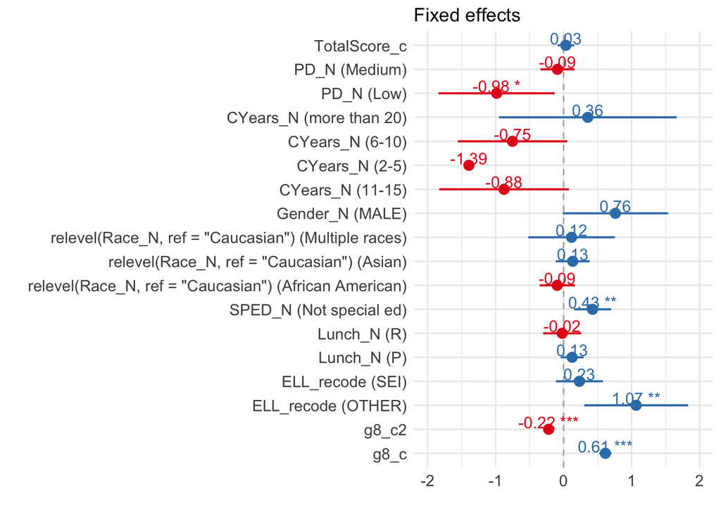

|  |  | B | CI | p |
| --- | --- | --- | --- | --- |
| Fixed Parts |  |  |  |  |
| (Intercept) |  | 0.59 | -0.32 – 1.50 | .207 |
| g8_c |  | 0.61 | 0.53 – 0.70 | <.001 |
| g8_c2 |  | -0.22 | -0.28 – -0.16 | <.001 |
| ELL_recode (OTHER) |  | 1.07 | 0.30 – 1.83 | .007 |
| ELL_recode (SEI) |  | 0.23 | -0.11 – 0.58 | .191 |
| Lunch_N (P) |  | 0.13 | -0.04 – 0.30 | .145 |
| Lunch_N (R) |  | -0.02 | -0.30 – 0.26 | .882 |
| SPED_N (Not special ed) |  | 0.43 | 0.15 – 0.70 | .003 |
| relevel(Race_N, ref = “Caucasian”) (African American) |  | -0.09 | -0.35 – 0.16 | .474 |
| relevel(Race_N, ref = “Caucasian”) (Asian) |  | 0.13 | -0.11 – 0.38 | .291 |
| relevel(Race_N, ref = “Caucasian”) (Multiple races) |  | 0.12 | -0.52 – 0.75 | .718 |
| Gender_N (MALE) |  | 0.76 | -0.01 – 1.54 | .055 |
| CYears_N (11-15) |  | -0.88 | -1.83 – 0.08 | .073 |
| CYears_N (2-5) |  | -1.39 | -2.99 – 0.21 | .089 |
| CYears_N (6-10) |  | -0.75 | -1.56 – 0.05 | .068 |
| CYears_N (more than 20) |  | 0.36 | -0.95 – 1.66 | .594 |
| PD_N (Low) |  | -0.98 | -1.84 – -0.13 | .025 |
| PD_N (Medium) |  | -0.09 | -0.34 – 0.16 | .480 |
| TotalScore_c |  | 0.03 | -0.09 – 0.16 | .594 |
| Random Parts |  |  |  |  |
| σ<sup>2</sup> |  | 0.282 |  |  |
| τ<sub>00, ID</sub> |  | 0.000 |  |  |
| N<sub>ID</sub> |  | 12 |  |  |
| ICC<sub>ID</sub> |  | 0.000 |  |  |
| Observations |  | 254 |  |  |
| R<sup>2</sup> / Ω<sub>0</sub><sup>2</sup> |  | .717 / .717 |  |  |

|  |  | B | CI | p |
| --- | --- | --- | --- | --- |
| Fixed Parts |  |  |  |  |
| (Intercept) |  | 0.59 | -0.32 – 1.50 | .207 |
| Grade 8 MCAS (z-score) |  | 0.61 | 0.53 – 0.70 | <.001 |
| Grade 8 MCAS^2 (z-score) |  | -0.22 | -0.28 – -0.16 | <.001 |
| ELL (Other) |  | 1.07 | 0.30 – 1.83 | .007 |
| ELL (SEI) |  | 0.23 | -0.11 – 0.58 | .191 |
| Lunch Status (P) |  | 0.13 | -0.04 – 0.30 | .145 |
| Lunch Status (R) |  | -0.02 | -0.30 – 0.26 | .882 |
| No SPED |  | 0.43 | 0.15 – 0.70 | .003 |
| African American Student |  | -0.09 | -0.35 – 0.16 | .474 |
| Asian Studnet |  | 0.13 | -0.11 – 0.38 | .291 |
| Multiple Races Student |  | 0.12 | -0.52 – 0.75 | .718 |
| Male Teacher |  | 0.76 | -0.01 – 1.54 | .055 |
| CYEARS (11-15) |  | -0.88 | -1.83 – 0.08 | .073 |
| CYEARS (2-5) |  | -1.39 | -2.99 – 0.21 | .089 |
| CYEARS (6-10) |  | -0.75 | -1.56 – 0.05 | .068 |
| CYEARS (More than 20) |  | 0.36 | -0.95 – 1.66 | .594 |
| PD (Low) |  | -0.98 | -1.84 – -0.13 | .025 |
| PD (Medium) |  | -0.09 | -0.34 – 0.16 | .480 |
| MHoM Total Score |  | 0.03 | -0.09 – 0.16 | .594 |
| Random Parts |  |  |  |  |
| σ<sup>2</sup> |  | 0.282 |  |  |
| τ<sub>00, ID</sub> |  | 0.000 |  |  |
| N<sub>ID</sub> |  | 12 |  |  |
| ICC<sub>ID</sub> |  | 0.000 |  |  |
| Observations |  | 254 |  |  |
| R<sup>2</sup> / Ω<sub>0</sub><sup>2</sup> |  | .717 / .717 |  |  |

## Model 6: Prior achievement + student characteristics + teacher characteristics + MHoM subscales

The model above is expanded by adding covariates for the teacher characteristics with the each susbscale from the MHoM measure.

### Model summary

```
## start par. =  0.6744288 fn =  420.964
## At return
## eval:  14 fn:      398.12957 par:  0.00000
```

```
## Linear mixed model fit by maximum likelihood t-tests use Satterthwaite
##   approximations to degrees of freedom [lmerMod]
## Formula:
## g10_c ~ g8_c + g8_c2 + ELL_recode + Lunch_N + SPED_N + relevel(Race_N,
##     ref = "Caucasian") + Gender_N + CYears_N + PD_N + Using_score_c +
##     Seeking_score_c + Describing_Score_c + (1 | ID)
##    Data: m_vars
##
##      AIC      BIC   logLik deviance df.resid
##    444.1    525.5   -199.1    398.1      231
##
## Scaled residuals:
##     Min      1Q  Median      3Q     Max
## -3.7062 -0.5469  0.0066  0.5151  3.1323
##
## Random effects:
##  Groups   Name        Variance Std.Dev.
##  ID       (Intercept) 0.0000   0.0000
##  Residual             0.2807   0.5298
## Number of obs: 254, groups:  ID, 12
##
## Fixed effects:
##                                                     Estimate Std. Error
## (Intercept)                                          0.83707    0.57582
## g8_c                                                 0.61931    0.04606
## g8_c2                                               -0.21967    0.03189
## ELL_recodeOTHER                                      1.08189    0.38942
## ELL_recodeSEI                                        0.21317    0.17833
## Lunch_NP                                             0.12113    0.08636
## Lunch_NR                                            -0.03243    0.14345
## SPED_NNot special ed                                 0.42388    0.13957
## relevel(Race_N, ref = "Caucasian")African American  -0.07596    0.13318
## relevel(Race_N, ref = "Caucasian")Asian              0.14024    0.12726
## relevel(Race_N, ref = "Caucasian")Multiple races     0.11926    0.32451
## Gender_NMALE                                         0.85406    0.42516
## CYears_N11-15                                       -1.02409    0.51391
## CYears_N2-5                                         -1.46344    0.83234
## CYears_N6-10                                        -1.00200    0.57853
## CYears_Nmore than 20                                 0.28727    0.70340
## PD_NLow                                             -1.11641    0.45770
```

[output cut: 35 more lines]

```
## relevel(Race_N, ref = "Caucasian")African American  0.56896
## relevel(Race_N, ref = "Caucasian")Asian             0.27150
## relevel(Race_N, ref = "Caucasian")Multiple races    0.71354
## Gender_NMALE                                        0.04561 *
## CYears_N11-15                                       0.04736 *
## CYears_N2-5                                         0.07992 .
## CYears_N6-10                                        0.08449 .
## CYears_Nmore than 20                                0.68332
## PD_NLow                                             0.01541 *
## PD_NMedium                                          0.31854
## Using_score_c                                       0.61556
## Seeking_score_c                                     0.46325
## Describing_Score_c                                  0.84040
## ---
## Signif. codes:  0 '***' 0.001 '**' 0.01 '*' 0.05 '.' 0.1 ' ' 1
```

```
##
## Correlation matrix not shown by default, as p = 21 > 12.
## Use print(x, correlation=TRUE)  or
##   vcov(x)     if you need it
```

[output not shown]

```
## Robust linear mixed model fit by DAStau
## Formula: g10_c ~ g8_c + g8_c2 + ELL_recode + Lunch_N + SPED_N + relevel(Race_N,      ref = "Caucasian") + Gender_N + CYears_N + PD_N + Using_score_c +      Seeking_score_c + Describing_Score_c + (1 | ID)
##    Data: m_vars
##
## Scaled residuals:
##     Min      1Q  Median      3Q     Max
## -5.1362 -0.5796 -0.0012  0.6180  3.5485
##
## Random effects:
##  Groups   Name        Variance Std.Dev.
##  ID       (Intercept) 0.0000   0.000
##  Residual             0.1989   0.446
## Number of obs: 254, groups: ID, 12
##
## Fixed effects:
##                                                    Estimate Std. Error
## (Intercept)                                         0.66186    0.49717
## g8_c                                                0.59422    0.03977
## g8_c2                                              -0.18430    0.02753
## ELL_recodeOTHER                                     0.95542    0.33623
## ELL_recodeSEI                                       0.17815    0.15397
## Lunch_NP                                            0.08087    0.07457
## Lunch_NR                                           -0.04019    0.12386
## SPED_NNot special ed                                0.39186    0.12050
## relevel(Race_N, ref = "Caucasian")African American  0.03351    0.11499
## relevel(Race_N, ref = "Caucasian")Asian             0.14960    0.10988
## relevel(Race_N, ref = "Caucasian")Multiple races   -0.08252    0.28019
## Gender_NMALE                                        0.71480    0.36709
## CYears_N11-15                                      -0.93150    0.44372
## CYears_N2-5                                        -1.20325    0.71866
## CYears_N6-10                                       -0.75368    0.49951
## CYears_Nmore than 20                                0.42706    0.60732
## PD_NLow                                            -1.01684    0.39518
## PD_NMedium                                         -0.14905    0.22993
## Using_score_c                                       0.02451    0.29046
## Seeking_score_c                                     0.04347    0.19614
## Describing_Score_c                                 -0.05046    0.15249
##                                                    t value
## (Intercept)                                          1.331
## g8_c                                                14.943
## g8_c2                                               -6.694
## ELL_recodeOTHER                                      2.842
## ELL_recodeSEI                                        1.157
## Lunch_NP                                             1.085
## Lunch_NR                                            -0.324
## SPED_NNot special ed                                 3.252
## relevel(Race_N, ref = "Caucasian")African American   0.291
## relevel(Race_N, ref = "Caucasian")Asian              1.361
## relevel(Race_N, ref = "Caucasian")Multiple races    -0.295
## Gender_NMALE                                         1.947
## CYears_N11-15                                       -2.099
## CYears_N2-5                                         -1.674
## CYears_N6-10                                        -1.509
## CYears_Nmore than 20                                 0.703
## PD_NLow                                             -2.573
## PD_NMedium                                          -0.648
## Using_score_c                                        0.084
## Seeking_score_c                                      0.222
## Describing_Score_c                                  -0.331
```

```
##
## Correlation matrix not shown by default, as p = 21 > 20.
## Use print(x, correlation=TRUE)  or
##   vcov(x)     if you need it
```

```
##
## Robustness weights for the residuals:
##  203 weights are ~= 1. The remaining 51 ones are summarized as
##    Min. 1st Qu.  Median    Mean 3rd Qu.    Max.
##   0.262   0.517   0.777   0.706   0.924   0.998
##
## Robustness weights for the random effects:
##  All 12 weights are ~= 1.
##
## Rho functions used for fitting:
##   Residuals:
##     eff: smoothed Huber (k = 1.345, s = 10)
##     sig: smoothed Huber, Proposal II (k = 1.345, s = 10)
##   Random Effects, variance component 1 (ID):
##     eff: smoothed Huber (k = 1.345, s = 10)
##     vcp: smoothed Huber, Proposal II (k = 1.345, s = 10)
```

```
##     term df      AIC      BIC    logLik deviance statistic Chi.Df
## 1    ..1 21 440.9707 515.2548 -199.4854 398.9707        NA     NA
## 2 object 23 444.1296 525.4883 -199.0648 398.1296 0.8411783      2
##     p.value
## 1        NA
## 2 0.6566598
```

The Nakagawa and Schielzeth (2013) method for calculating the proportion of variance explained by the fixed predictors

|  | Effect | F | v1 | v2 | ncp | Rsq | upper.CL | lower.CL |
| --- | --- | --- | --- | --- | --- | --- | --- | --- |
| 1 | Model | 32.365 | 20 | 253 | 647.290 | 0.719 | 0.769 | 0.677 |
| 2 | g8_c | 180.812 | 1 | 253 | 180.812 | 0.417 | 0.498 | 0.334 |
| 3 | g8_c2 | 47.457 | 1 | 253 | 47.457 | 0.158 | 0.243 | 0.086 |
| 8 | SPED_NNot special ed | 9.224 | 1 | 253 | 9.224 | 0.035 | 0.092 | 0.005 |
| 4 | ELL_recodeOTHER | 7.719 | 1 | 253 | 7.719 | 0.030 | 0.083 | 0.003 |
| 17 | PD_NLow | 5.950 | 1 | 253 | 5.950 | 0.023 | 0.072 | 0.001 |
| 12 | Gender_NMALE | 4.035 | 1 | 253 | 4.035 | 0.016 | 0.060 | 0.000 |
| 13 | CYears_N11-15 | 3.971 | 1 | 253 | 3.971 | 0.015 | 0.059 | 0.000 |
| 14 | CYears_N2-5 | 3.091 | 1 | 253 | 3.091 | 0.012 | 0.053 | 0.000 |
| 15 | CYears_N6-10 | 3.000 | 1 | 253 | 3.000 | 0.012 | 0.052 | 0.000 |
| 6 | Lunch_NP | 1.967 | 1 | 253 | 1.967 | 0.008 | 0.043 | 0.000 |
| 5 | ELL_recodeSEI | 1.429 | 1 | 253 | 1.429 | 0.006 | 0.038 | 0.000 |
| 10 | relevel(Race_N, ref = “Caucasian”)Asian | 1.214 | 1 | 253 | 1.214 | 0.005 | 0.036 | 0.000 |
| 18 | PD_NMedium | 0.999 | 1 | 253 | 0.999 | 0.004 | 0.034 | 0.000 |
| 20 | Seeking_score_c | 0.540 | 1 | 253 | 0.540 | 0.002 | 0.028 | 0.000 |
| 9 | relevel(Race_N, ref = “Caucasian”)African American | 0.325 | 1 | 253 | 0.325 | 0.001 | 0.025 | 0.000 |
| 19 | Using_score_c | 0.253 | 1 | 253 | 0.253 | 0.001 | 0.024 | 0.000 |
| 16 | CYears_Nmore than 20 | 0.167 | 1 | 253 | 0.167 | 0.001 | 0.023 | 0.000 |
| 11 | relevel(Race_N, ref = “Caucasian”)Multiple races | 0.135 | 1 | 253 | 0.135 | 0.001 | 0.022 | 0.000 |
| 7 | Lunch_NR | 0.051 | 1 | 253 | 0.051 | 0.000 | 0.021 | 0.000 |
| 21 | Describing_Score_c | 0.041 | 1 | 253 | 0.041 | 0.000 | 0.020 | 0.000 |

Useful plots for the model are found below.

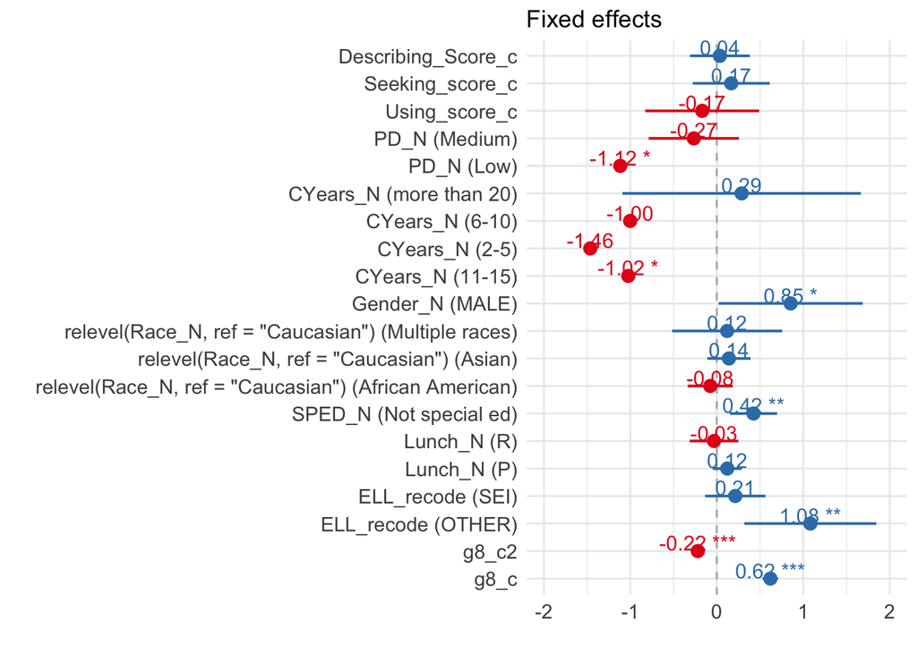

|  |  | B | CI | p |
| --- | --- | --- | --- | --- |
| Fixed Parts |  |  |  |  |
| (Intercept) |  | 0.84 | -0.29 – 1.97 | .147 |
| Grade 8 MCAS (z-score) |  | 0.62 | 0.53 – 0.71 | <.001 |
| Grade 8 MCAS^2 (z-score) |  | -0.22 | -0.28 – -0.16 | <.001 |
| ELL (Other) |  | 1.08 | 0.32 – 1.85 | .006 |
| ELL (SEI) |  | 0.21 | -0.14 – 0.56 | .233 |
| Lunch Status (P) |  | 0.12 | -0.05 – 0.29 | .162 |
| Lunch Status (R) |  | -0.03 | -0.31 – 0.25 | .821 |
| No SPED |  | 0.42 | 0.15 – 0.70 | .003 |
| African American Student |  | -0.08 | -0.34 – 0.19 | .569 |
| Asian Studnet |  | 0.14 | -0.11 – 0.39 | .272 |
| Multiple Races Student |  | 0.12 | -0.52 – 0.76 | .714 |
| Male Teacher |  | 0.85 | 0.02 – 1.69 | .046 |
| CYEARS (11-15) |  | -1.02 | -2.03 – -0.02 | .047 |
| CYEARS (2-5) |  | -1.46 | -3.09 – 0.17 | .080 |
| CYEARS (6-10) |  | -1.00 | -2.14 – 0.13 | .084 |
| CYEARS (More than 20) |  | 0.29 | -1.09 – 1.67 | .683 |
| PD (Low) |  | -1.12 | -2.01 – -0.22 | .015 |
| PD (Medium) |  | -0.27 | -0.79 – 0.26 | .319 |
| MHoM Using |  | -0.17 | -0.83 – 0.49 | .616 |
| MHoM Seeking |  | 0.17 | -0.28 – 0.61 | .463 |
| MHoM Describing |  | 0.04 | -0.31 – 0.38 | .840 |
| Random Parts |  |  |  |  |
| σ<sup>2</sup> |  | 0.281 |  |  |
| τ<sub>00, ID</sub> |  | 0.000 |  |  |
| N<sub>ID</sub> |  | 12 |  |  |
| ICC<sub>ID</sub> |  | 0.000 |  |  |
| Observations |  | 254 |  |  |
| R<sup>2</sup> / Ω<sub>0</sub><sup>2</sup> |  | .718 / .718 |  |  |